# The Persevering Path of the US Dollar's Value Across the Last Three Presidencies

## Introduction

#### The first purpose of this project is to ascertain how the Euro to USD value fluctuated during the last three presidencies in the United States of America (as of January 2021). The [dataset](https://www.kaggle.com/lsind18/euro-exchange-daily-rates-19992020) was provided by the European Central Bank and is hosted and continously updated on Kaggle by Daria Chemkaeva. The second purpose is to engage in this project in order to particularly improve data visualization skills.

## Summary of Results

#### The worst value for the Euro to USD conversion was almost 1.6 between 2007 and 2008, a timeframe in which a great recession took place. It later hovered around 1.4 for 5 years, from 2009 to 2014. Since 2015, it remained mostly below 1.2. However, as of 2021, it is slightly above 1.2. Lastly, the total average for the entire period was 1.22. There is a graph that demonstrates this, which was one of the objectives of this project. What follows this section is the cleaning of the data and the plotting of the main graph.

### Learning About the Data's Structure

```python
#Reading the file into pandas

import pandas as pd

exchange_rates = pd.read_csv('euro-daily-hist_1999_2020.csv')

#Inspecting the data

exchange_rates.head()
```

|  | Period\Unit: | [Australian dollar ] | [Bulgarian lev ] | [Brazilian real ] | [Canadian dollar ] | [Swiss franc ] | [Chinese yuan renminbi ] | [Cypriot pound ] | [Czech koruna ] | [Danish krone ] | ... | [Romanian leu ] | [Russian rouble ] | [Swedish krona ] | [Singapore dollar ] | [Slovenian tolar ] | [Slovak koruna ] | [Thai baht ] | [Turkish lira ] | [US dollar ] | [South African rand ] |
| --- | --- | --- | --- | --- | --- | --- | --- | --- | --- | --- | --- | --- | --- | --- | --- | --- | --- | --- | --- | --- | --- |
| 0 | 2021-01-08 | 1.5758 | 1.9558 | 6.5748 | 1.5543 | 1.0827 | 7.9184 | NaN | 26.163 | 7.4369 | ... | 4.8708 | 90.8000 | 10.0510 | 1.6228 | NaN | NaN | 36.8480 | 9.0146 | 1.2250 | 18.7212 |
| 1 | 2021-01-07 | 1.5836 | 1.9558 | 6.5172 | 1.5601 | 1.0833 | 7.9392 | NaN | 26.147 | 7.4392 | ... | 4.8712 | 91.2000 | 10.0575 | 1.6253 | NaN | NaN | 36.8590 | 8.9987 | 1.2276 | 18.7919 |
| 2 | 2021-01-06 | 1.5824 | 1.9558 | 6.5119 | 1.5640 | 1.0821 | 7.9653 | NaN | 26.145 | 7.4393 | ... | 4.8720 | 90.8175 | 10.0653 | 1.6246 | NaN | NaN | 36.9210 | 9.0554 | 1.2338 | 18.5123 |
| 3 | 2021-01-05 | 1.5927 | 1.9558 | 6.5517 | 1.5651 | 1.0803 | 7.9315 | NaN | 26.227 | 7.4387 | ... | 4.8721 | 91.6715 | 10.0570 | 1.6180 | NaN | NaN | 36.7760 | 9.0694 | 1.2271 | 18.4194 |
| 4 | 2021-01-04 | 1.5928 | 1.9558 | 6.3241 | 1.5621 | 1.0811 | 7.9484 | NaN | 26.141 | 7.4379 | ... | 4.8713 | 90.3420 | 10.0895 | 1.6198 | NaN | NaN | 36.7280 | 9.0579 | 1.2296 | 17.9214 |

5 rows × 41 columns

```python
#Inspecting the last few records

exchange_rates.tail()
```

|  | Period\Unit: | [Australian dollar ] | [Bulgarian lev ] | [Brazilian real ] | [Canadian dollar ] | [Swiss franc ] | [Chinese yuan renminbi ] | [Cypriot pound ] | [Czech koruna ] | [Danish krone ] | ... | [Romanian leu ] | [Russian rouble ] | [Swedish krona ] | [Singapore dollar ] | [Slovenian tolar ] | [Slovak koruna ] | [Thai baht ] | [Turkish lira ] | [US dollar ] | [South African rand ] |
| --- | --- | --- | --- | --- | --- | --- | --- | --- | --- | --- | --- | --- | --- | --- | --- | --- | --- | --- | --- | --- | --- |
| 5694 | 1999-01-08 | 1.8406 | NaN | NaN | 1.7643 | 1.6138 | NaN | 0.58187 | 34.938 | 7.4433 | ... | 1.3143 | 27.2075 | 9.1650 | 1.9537 | 188.8400 | 42.560 | 42.5590 | 0.3718 | 1.1659 | 6.7855 |
| 5695 | 1999-01-07 | 1.8474 | NaN | NaN | 1.7602 | 1.6165 | NaN | 0.58187 | 34.886 | 7.4431 | ... | 1.3092 | 26.9876 | 9.1800 | 1.9436 | 188.8000 | 42.765 | 42.1678 | 0.3701 | 1.1632 | 6.8283 |
| 5696 | 1999-01-06 | 1.8820 | NaN | NaN | 1.7711 | 1.6116 | NaN | 0.58200 | 34.850 | 7.4452 | ... | 1.3168 | 27.4315 | 9.3050 | 1.9699 | 188.7000 | 42.778 | 42.6949 | 0.3722 | 1.1743 | 6.7307 |
| 5697 | 1999-01-05 | 1.8944 | NaN | NaN | 1.7965 | 1.6123 | NaN | 0.58230 | 34.917 | 7.4495 | ... | 1.3168 | 26.5876 | 9.4025 | 1.9655 | 188.7750 | 42.848 | 42.5048 | 0.3728 | 1.1790 | 6.7975 |
| 5698 | 1999-01-04 | 1.9100 | NaN | NaN | 1.8004 | 1.6168 | NaN | 0.58231 | 35.107 | 7.4501 | ... | 1.3111 | 25.2875 | 9.4696 | 1.9554 | 189.0450 | 42.991 | 42.6799 | 0.3723 | 1.1789 | 6.9358 |

5 rows × 41 columns

```python
#Verifying to see if there are missing rows

exchange_rates.info()
```

```
<class 'pandas.core.frame.DataFrame'>
RangeIndex: 5699 entries, 0 to 5698
Data columns (total 41 columns):
 #   Column                    Non-Null Count  Dtype
---  ------                    --------------  -----
 0   Period\Unit:              5699 non-null   object
 1   [Australian dollar ]      5699 non-null   object
 2   [Bulgarian lev ]          5297 non-null   object
 3   [Brazilian real ]         5431 non-null   object
 4   [Canadian dollar ]        5699 non-null   object
 5   [Swiss franc ]            5699 non-null   object
 6   [Chinese yuan renminbi ]  5431 non-null   object
 7   [Cypriot pound ]          2346 non-null   object
 8   [Czech koruna ]           5699 non-null   object
 9   [Danish krone ]           5699 non-null   object
```

[output cut: 33 more lines]

#### There are a high number of null values for multiple currencies. However, the focus is going to be the US dollar, which seems to be complete, especially when comparing it to other currencies with 5,699 rows. The next steps will be to clean the dates and the currency because they have an object format.

### Creating a Dataframe Centered Around the USD

#### The first step is to reset the index of the records for the purpose of starting with the oldest year instead of the most recent one. In addition, turning the dates into datetime objects.

```python
exchange_rates.rename(columns={'[US dollar ]': 'US_dollar',
                               'Period\\Unit:': 'Time'},
                      inplace=True)

exchange_rates['Time'] = pd.to_datetime(exchange_rates['Time'])

exchange_rates.sort_values('Time', inplace=True)

exchange_rates.reset_index(drop=True,inplace=True)

print('The "Time" column\'s new datatype : ',
      exchange_rates['Time'].dtype)

exchange_rates.tail()
```

```
The "Time" column's new datatype :  datetime64[ns]
```

|  | Time | [Australian dollar ] | [Bulgarian lev ] | [Brazilian real ] | [Canadian dollar ] | [Swiss franc ] | [Chinese yuan renminbi ] | [Cypriot pound ] | [Czech koruna ] | [Danish krone ] | ... | [Romanian leu ] | [Russian rouble ] | [Swedish krona ] | [Singapore dollar ] | [Slovenian tolar ] | [Slovak koruna ] | [Thai baht ] | [Turkish lira ] | US_dollar | [South African rand ] |
| --- | --- | --- | --- | --- | --- | --- | --- | --- | --- | --- | --- | --- | --- | --- | --- | --- | --- | --- | --- | --- | --- |
| 5694 | 2021-01-04 | 1.5928 | 1.9558 | 6.3241 | 1.5621 | 1.0811 | 7.9484 | NaN | 26.141 | 7.4379 | ... | 4.8713 | 90.3420 | 10.0895 | 1.6198 | NaN | NaN | 36.7280 | 9.0579 | 1.2296 | 17.9214 |
| 5695 | 2021-01-05 | 1.5927 | 1.9558 | 6.5517 | 1.5651 | 1.0803 | 7.9315 | NaN | 26.227 | 7.4387 | ... | 4.8721 | 91.6715 | 10.0570 | 1.6180 | NaN | NaN | 36.7760 | 9.0694 | 1.2271 | 18.4194 |
| 5696 | 2021-01-06 | 1.5824 | 1.9558 | 6.5119 | 1.5640 | 1.0821 | 7.9653 | NaN | 26.145 | 7.4393 | ... | 4.8720 | 90.8175 | 10.0653 | 1.6246 | NaN | NaN | 36.9210 | 9.0554 | 1.2338 | 18.5123 |
| 5697 | 2021-01-07 | 1.5836 | 1.9558 | 6.5172 | 1.5601 | 1.0833 | 7.9392 | NaN | 26.147 | 7.4392 | ... | 4.8712 | 91.2000 | 10.0575 | 1.6253 | NaN | NaN | 36.8590 | 8.9987 | 1.2276 | 18.7919 |
| 5698 | 2021-01-08 | 1.5758 | 1.9558 | 6.5748 | 1.5543 | 1.0827 | 7.9184 | NaN | 26.163 | 7.4369 | ... | 4.8708 | 90.8000 | 10.0510 | 1.6228 | NaN | NaN | 36.8480 | 9.0146 | 1.2250 | 18.7212 |

5 rows × 41 columns

#### It looks good. The next step is to take a further look at the 'Time' and 'US_dollar' columns.

```python
euro_to_dollar = exchange_rates[['Time', 'US_dollar']]

euro_to_dollar['US_dollar'].value_counts()
```

```
-         62
1.2276     9
1.1215     8
1.1305     7
1.3532     6
          ..
0.9687     1
1.4155     1
1.3195     1
1.4471     1
1.4462     1
Name: US_dollar, Length: 3528, dtype: int64
```

#### There are too many '-' values, so those will be dropped. In addition, the 'US_dollar' column will be converted to a float data type.

```python
rows_to_keep = euro_to_dollar['US_dollar'] != '-'

euro_to_dollar = euro_to_dollar[rows_to_keep]

euro_to_dollar['US_dollar'] = (euro_to_dollar
                               ['US_dollar'].astype(float))

print(euro_to_dollar['US_dollar'].value_counts())

print('\n','"USD" column\'s new datatype : ',
      euro_to_dollar['US_dollar'].dtype)
```

```
1.2276    9
1.1215    8
1.1305    7
1.1268    6
1.3373    6
         ..
1.4639    1
1.5206    1
1.3272    1
0.8591    1
0.9375    1
Name: US_dollar, Length: 3527, dtype: int64

 "USD" column's new datatype :  float64
```

#### With this step complete, a test graph can be run. For this test, the change of the USD's value over time will be plotted, since the dataset starts in 1999.

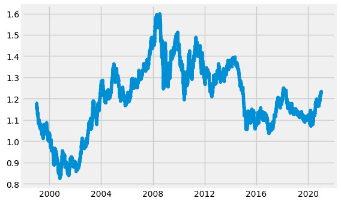

```python
#Running a test plot

import matplotlib.pyplot as plt
%matplotlib inline

plt.plot(euro_to_dollar['Time'],euro_to_dollar['US_dollar'])
```

### The USD's Value Since 1999 : Rolling Mean Test Plot

#### Smoothing out the lines of the plot above is necessary for focusing on long term trends. To address this, a rolling mean with a window of 30 days will be utilized.

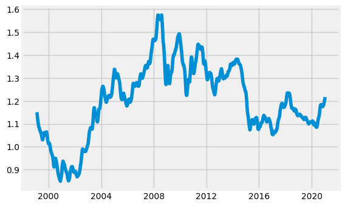

```python
euro_to_dollar['Rolling_mean_30'] =(euro_to_dollar
                                    ['US_dollar'].rolling(30).mean())

plt.plot(euro_to_dollar['Time'],euro_to_dollar['Rolling_mean_30'])
```

#### Since this change will help the legibility and usability of the graphs, the focus will now be shifted to making the final graph.

### The Euro to USD Value's Change Throughout the Last Three Presidencies

#### The final plot is meant to portray the change of the Euro-USD value across the tenures of the last three US Presidents: George W. Bush, Barack Obama, and Donald Trump. It will capture a period that begins in 2001 and ends in 2021, which amounts to a total of 20 years. To accomplish this, the main objective is to create two snapshots of sorts, one section with a line plot for each of the tenures and another with a line plot combining all of the tenures.

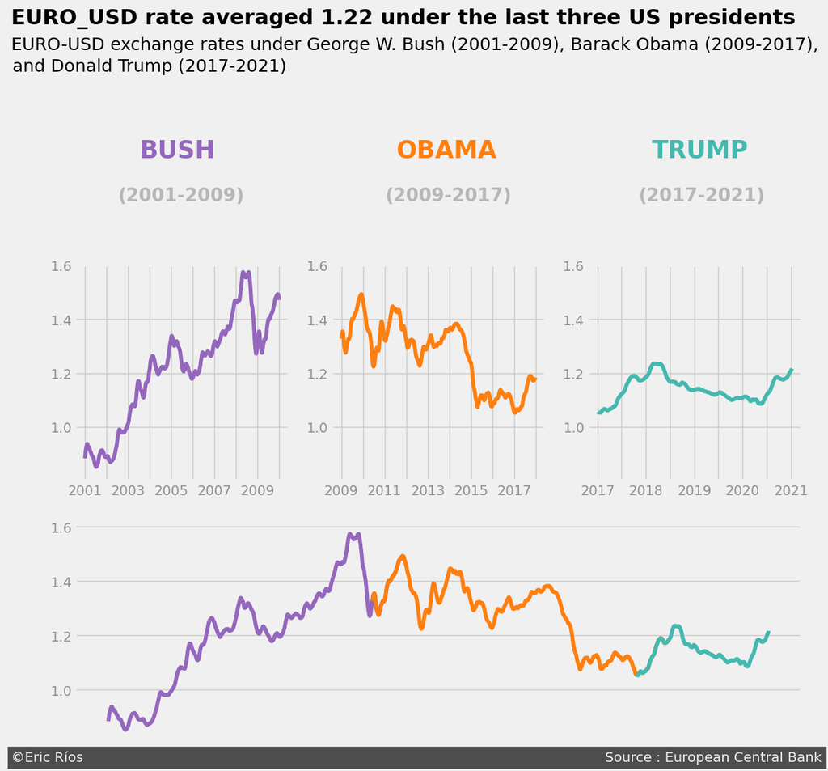

```python
#Importing the style module
import matplotlib.style as style
style.use('fivethirtyeight')

#Preparing the figure
fig = plt.figure (figsize = (12,13))

#These are the individual plots for each of the Presidents,
#the first section of the graph.
#The labels were placed in plots due to image size errors.

ax1_label = fig.add_subplot(3,3, 1)
ax2_label = fig.add_subplot(3,3, 2)
ax3_label = fig.add_subplot(3,3, 3)
ax1 = fig.add_subplot(3,3, 4)
ax2 = fig.add_subplot(3,3, 5)
ax3 = fig.add_subplot(3,3, 6)

#The combined plot to cover the second section of the graph
ax4 = fig.add_subplot(3,3, (7,9))


#Preparing the pairings used for the loop

label_spots = [ax1_label,ax2_label,ax3_label]
label_x = [0.2, 0.25, 0.235] #The x_coordinates of the tenure labels
ax_list = [ax1,ax2,ax3]
labels = ['BUSH', 'OBAMA', 'TRUMP']
tenures = [(2001,2009),(2009,2017),(2017,2021)]
colors = ['#9467bd', '#ff7f0e','#45b8b0']

pairings = zip(label_spots, label_x, ax_list, labels,
               tenures, colors)

for label_spot, x, ax, name, tenure, colour in pairings:

    #Plotting a line plot per ax for ax1, ax2, and ax3
    #as well as ax4, which will house all three line plots

    timeframe = '{}-01-01, {}-12-31'.format(tenure[0],tenure[1])

    beginning, end = timeframe.split()

    Time_bool = euro_to_dollar['Time'].between(beginning,end)

    ax.plot(euro_to_dollar[Time_bool]['Time'],
            euro_to_dollar[Time_bool]['Rolling_mean_30'],
            c = colour, linewidth = 4)

    ax.set_ylim(bottom = 0.8,top = 1.6)

    ax.set_yticklabels(['',1.0,1.2,1.4,1.6], alpha = 0.4)

    ax4.plot(euro_to_dollar[Time_bool]['Time'],
            euro_to_dollar[Time_bool]['Rolling_mean_30'], c = colour,
            linewidth = 4)


    #Editing the axes ax1_label, ax2_label, ax3_label
    #to accomodate the Presidents' name and tenure labels

    label_spot.grid(b=None)

    label_spot.set_xticklabels([])

    label_spot.set_yticklabels([])

    label_spot.text(0.3, 0.3, name, c = colour,
                    fontsize = 25, fontweight = 'bold')

    tenure_label = '({}-{})'.format(tenure[0], tenure[1])

    label_spot.text(x, 0.1, tenure_label, c = 'grey',
                    fontsize = 19, fontweight = 'bold', alpha = 0.5)


    #Tweaking the xticks to improve the readability of labels
    #along the x-axis of the graph

    tenure_gap = tenure[1]-tenure[0]

    n = tenure[0]

    #n is used to improve the readability of the argument
    #of ax.set_xticklabels

    if tenure_gap > 4:

        simplified_xticks = [' ', n, ' ', n + 2, ' ', n + 4, ' ',
                             n + 6 , ' ', n + 8]

    else:

        simplified_xticks = [n, ' ', n + 1, ' ', n + 2, ' ',
                             n + 3 , ' ', n + 4]

    ax.set_xticklabels(simplified_xticks, alpha = 0.4)



#Final aesthetic changes for ax4, the ax with all the line plots

ax4.grid(b=None, which='major', axis='x')

ax4.set_yticklabels(['',1.0,1.2,1.4,1.6], alpha = 0.4)

ax4.set_xticklabels([])


#This part of the code covers the calculation of the averages
#to be used for the titles.

all_tenures_bool = euro_to_dollar['Time'].between('2001-01-01',
                                             '2021-12-31')

all_tenures_avg = (euro_to_dollar[all_tenures_bool]
                   ['Rolling_mean_30'].mean())


#The creation of the titles, subdivided for the code's readability

title_part_1 = 'EURO_USD rate averaged {:,.2f} under the last three'

title_part_2 = ' US presidents'

title_string = (title_part_1 + title_part_2).format(all_tenures_avg)

ax3_label.text(-2.7,0.92,title_string,
               fontweight = 'bold', fontsize = 22)


subtitle_part_1 = 'EURO-USD exchange rates under George W. Bush '

subtitle_part_2 = '(2001-2009), Barack Obama (2009-2017),'

subtitle_part_3 = ' and Donald Trump (2017-2021)'


#The reason for the following split is to maintain the readability
#of the subtitle in the graph as well as the code.

subtitle_A = subtitle_part_1 + subtitle_part_2

subtitle_B = subtitle_part_3

ax3_label.text(-2.7, 0.8, subtitle_A, fontsize = 18)

ax3_label.text(-2.72, 0.7, subtitle_B, fontsize = 18)


# Finalizing the graph with the signature

ax2_label.text(-1.5,-2.5,'©Eric Ríos' + ' '*120 +
               'Source : European Central Bank',
               backgroundcolor = '#4d4d4d', c = '#f0f0f0')


plt.show()
```

## Conclusion

#### The objective was to track and show the Euro-USD value's changes throughout the combined tenures of the last three presidents, ranging from 2001 until 2021. The approach consisted of cleaning the data by fixing formats, removing empty records, and applying the use of the rolling mean. All of these steps paved the way for the main graph. Said graph consisted of plots showing the USD values changing during each President's tenure as well as collectively across them.

#### At its worst state, the USD value was almost 1.6 (2007-2008), and its worst overall period was between 2008 and 2012. After roughly thirteen to fourteen years, it managed to place near 1.2, although it was slightly rising towards the beginning of 2021. In addition, it also averaged a value of 1.22 for the entire timeframe. Lastly, as food for thought, a potential and future variant for this study could examine the changes of the currency's value during the Coronavirus pandemic.